# Demographic Impact on Economic Growth

Conclusion: The models generally satisfy the basic assumptions of linear regression (linearity, homoscedasticity), but the outliers identified (47, 51, 81) require further removal.

```r
# Load necessary libraries
library(knitr)
library(kableExtra)

# Remove rows 47, 51, and 81 by subsetting
data_cleaned <- data_2015[-c(47, 51, 81), ]
removed_data <- data_2015[c(47, 51, 81), ]

# Display removed data in a formatted table
kable(removed_data, format = "html", table.attr = "style='width:50%; margin-left:auto; margin-right:auto;'") %>%
  kable_styling(full_width = FALSE, bootstrap_options = c("striped", "hover", "condensed", "responsive"))
```

|  | country | year | pop_growth | gdp_growth | age_0_14 | age_15_64 | age_65_plus | primary_enrollment | secondary_enrollment | educational_attainment | income_level | pop_total | gdp_real |
| --- | --- | --- | --- | --- | --- | --- | --- | --- | --- | --- | --- | --- | --- |
| 47 | Ireland | 2015 | 0.9448453 | 24.615570 | 21.31797 | 65.57177 | 13.110254 | 101.1846 | 116.9899 | 99.03454 | High income | 4701957 | 302391428540 |
| 51 | Kiribati | 2015 | 1.2828586 | 11.265338 | 35.16672 | 61.14925 | 3.684030 | 104.8557 | NA | 92.85597 | Lower middle income | 116815 | 191559398 |
| 81 | Qatar | 2015 | 8.5817331 | 4.753346 | 13.94874 | 85.00042 | 1.050846 | 101.9824 | 101.9468 | 86.44083 | High income | 2344557 | 161739955577 |

The table contains data from the outlier countries that were removed from the analysis: Ireland, Kiribati and Qatar. These countries are highlighted by extreme values, such as Qatar’s population growth rate of 8.58% and Ireland’s GDP growth rate of 24.6%, as well as specific age structure and economic characteristics. Removing these points improves the quality of the model by removing the influence of anomalous data.

```r
# Load necessary libraries
library(broom)
library(knitr)
library(kableExtra)

# Fit the models
model_cleaned <- lm(gdp_growth ~ pop_growth + income_level + age_65_plus, data = data_cleaned)
model_cleaned_pop <- lm(gdp_growth ~ pop_growth, data = data_cleaned)

# Summarize the models
summary_cleaned <- tidy(model_cleaned)
summary_cleaned_pop <- tidy(model_cleaned_pop)

# Create tables
cat("\nModel: gdp_growth ~ pop_growth + income_level + age_65_plus\n")
```

```
Model: gdp_growth ~ pop_growth + income_level + age_65_plus
```

```r
kable(summary_cleaned, format = "html", table.attr = "style='width:80%; margin-left:auto; margin-right:auto;'") %>%
  kable_styling(full_width = FALSE, bootstrap_options = c("striped", "hover", "condensed", "responsive"))
```

| term | estimate | std.error | statistic | p.value |
| --- | --- | --- | --- | --- |
| (Intercept) | 2.2944003 | 1.3515371 | 1.6976229 | 0.0926890 |
| pop_growth | 0.3849571 | 0.2857538 | 1.3471638 | 0.1809723 |
| income_levelLow income | 1.3109521 | 1.0497943 | 1.2487704 | 0.2146646 |
| income_levelLower middle income | 0.5886462 | 0.8370982 | 0.7031984 | 0.4835661 |
| income_levelUpper middle income | 0.0783020 | 0.6896661 | 0.1135361 | 0.9098332 |
| age_65_plus | 0.0025227 | 0.0756163 | 0.0333616 | 0.9734527 |

```r
cat("\nModel: gdp_growth ~ pop_growth\n")
```

```
Model: gdp_growth ~ pop_growth
```

```r
kable(summary_cleaned_pop, format = "html", table.attr = "style='width:80%; margin-left:auto; margin-right:auto;'") %>%
  kable_styling(full_width = FALSE, bootstrap_options = c("striped", "hover", "condensed", "responsive"))
```

| term | estimate | std.error | statistic | p.value |
| --- | --- | --- | --- | --- |
| (Intercept) | 2.4015548 | 0.2879599 | 8.339892 | 0.0000000 |
| pop_growth | 0.5447942 | 0.1704915 | 3.195434 | 0.0018489 |

The first model shows that none of the factors (pop_growth, income_level, age_65_plus) has a statistically significant effect on GDP growth, e.g., for pop_growth p = 0.181. The second model shows that population growth has a significant positive effect (coefficient = 0.545, p = 0.0018), increasing GDP by 0.545% for a population growth of 1%. The intersept of the second model (2.40, p < 0.001) reflects the average level of GDP growth without the influence of population growth. The overall conclusion is that population growth is important for GDP, but the other included variables explain little of its variation.

Upon analyzing the multiple linear regression model, we observe that removing outliers has improved the model’s performance. When comparing the full model, which includes all variables, to a simpler model that only considers population growth, we find that population growth significantly influences GDP growth. However, the model is not solely explained by this variable. The inclusion of other parameters does not enhance the model’s explanatory power; instead, they introduce noise and do not have a significant effect on GDP growth. This suggests that while population growth is a key determinant of GDP growth, other factors may not be as impactful in this context. The presence of non-significant variables can lead to overfitting, where the model captures random noise rather than underlying patterns. Therefore, it is advisable to focus on variables that have a meaningful and statistically significant relationship with the dependent variable to improve model accuracy and interpretability.

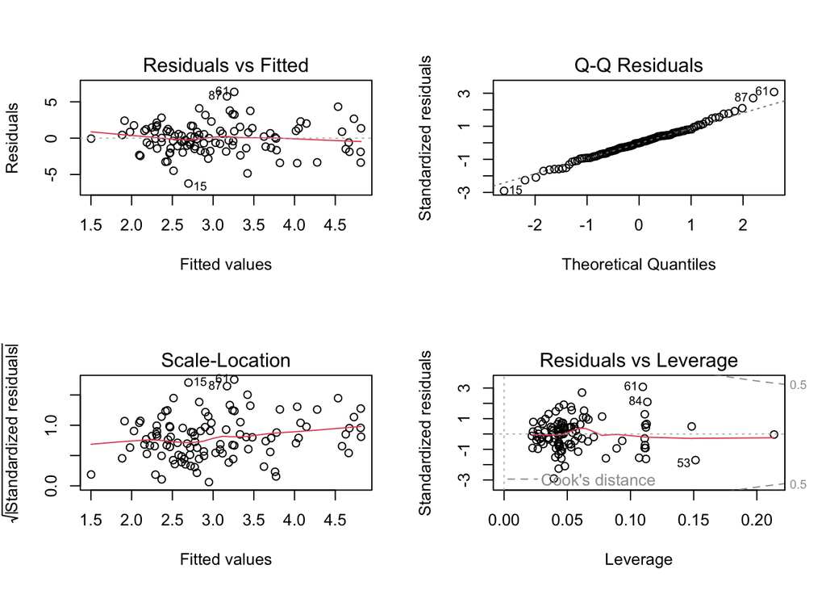

```r
#model with all variables
par(mfrow = c(2, 2))
plot(model_cleaned)
```

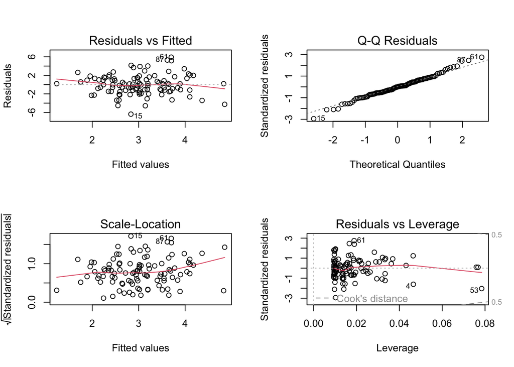

```r
par(mfrow = c(1, 1))

#model with gdp ~ pop growth
par(mfrow = c(2, 2))
plot(model_cleaned_pop)
```

```r
par(mfrow = c(1, 1))
```

The graphs show that the model generally meets key statistical assumptions, including linearity, normality of residuals and homoscedasticity, which confirms its suitability for analysis and forecasting. However, deviations of the residuals at the edges of the distribution indicate possible limitations of the model for extreme values of the predictors, which may reduce accuracy in these areas. Points with high influence, such as 87 and 610, although identified as outliers, do not significantly distort the model (Cook’s distance < 0.5), indicating its robustness. At the same time, further work with outliers and analysis of anomalous observations can improve the accuracy and explanatory power of the model.

## 4.4 Panel Model

```r
# Load necessary libraries
library(plm)
library(dplyr)
library(knitr)
library(kableExtra)
library(ggplot2)

# Convert to pdata.frame for panel data
panel_data <- pdata.frame(wdi_data, index = c("country", "year"))

# Build fixed effects model for population growth
fixed_model <- plm(gdp_growth ~ pop_growth, data = panel_data, model = "within")

# Summarize results for groups by income level
low_income_data <- pdata.frame(wdi_data %>% filter(income_level == "Low income"), index = c("country", "year"))
lower_middle_income_data <- pdata.frame(wdi_data %>% filter(income_level == "Lower middle income"), index = c("country", "year"))
upper_middle_income_data <- pdata.frame(wdi_data %>% filter(income_level == "Upper middle income"), index = c("country", "year"))
high_income_data <- pdata.frame(wdi_data %>% filter(income_level == "High income"), index = c("country", "year"))

# Build models for each income group
fixed_model_low <- plm(gdp_growth ~ pop_growth, data = low_income_data, model = "within")
fixed_model_lower_middle <- plm(gdp_growth ~ pop_growth, data = lower_middle_income_data, model = "within")
fixed_model_upper_middle <- plm(gdp_growth ~ pop_growth, data = upper_middle_income_data, model = "within")
fixed_model_high <- plm(gdp_growth ~ pop_growth, data = high_income_data, model = "within")

# Combine results into a single table
results_table <- data.frame(
  Income_Level = c("Low income", "Lower middle income", "Upper middle income", "High income"),
  Coefficient = c(coef(fixed_model_low)["pop_growth"],
                  coef(fixed_model_lower_middle)["pop_growth"],
                  coef(fixed_model_upper_middle)["pop_growth"],
                  coef(fixed_model_high)["pop_growth"]),
  Std_Error = c(summary(fixed_model_low)$coefficients["pop_growth", "Std. Error"],
                summary(fixed_model_lower_middle)$coefficients["pop_growth", "Std. Error"],
                summary(fixed_model_upper_middle)$coefficients["pop_growth", "Std. Error"],
                summary(fixed_model_high)$coefficients["pop_growth", "Std. Error"]),
  p_value = c(summary(fixed_model_low)$coefficients["pop_growth", "Pr(>|t|)"],
              summary(fixed_model_lower_middle)$coefficients["pop_growth", "Pr(>|t|)"],
              summary(fixed_model_upper_middle)$coefficients["pop_growth", "Pr(>|t|)"],
              summary(fixed_model_high)$coefficients["pop_growth", "Pr(>|t|)"]),
  R_Squared = c(summary(fixed_model_low)$r.squared,
                summary(fixed_model_lower_middle)$r.squared,
                summary(fixed_model_upper_middle)$r.squared,
                summary(fixed_model_high)$r.squared)
)

# Display results table
kable(results_table, format = "html", table.attr = "style='width:100%; margin:auto;'") %>%
  kable_styling(full_width = TRUE, bootstrap_options = c("striped", "hover", "condensed", "responsive"))
```

| Income_Level | Coefficient | Std_Error | p_value | R_Squared |
| --- | --- | --- | --- | --- |
| Low income | 4.5124893 | 1.5544935 | 0.0049228 | 0.1060934 |
| Lower middle income | 0.7065800 | 0.8362857 | 0.3991407 | -0.1960722 |
| Upper middle income | -0.3557426 | 0.7129554 | 0.6181770 | 0.0034367 |
| High income | 0.1644599 | 0.1485692 | 0.2689224 | -0.2517220 |
| Low income | 4.5124893 | 1.5544935 | 0.0049228 | 0.0008519 |
| Lower middle income | 0.7065800 | 0.8362857 | 0.3991407 | -0.1633916 |
| Upper middle income | -0.3557426 | 0.7129554 | 0.6181770 | 0.0028026 |
| High income | 0.1644599 | 0.1485692 | 0.2689224 | -0.1390007 |

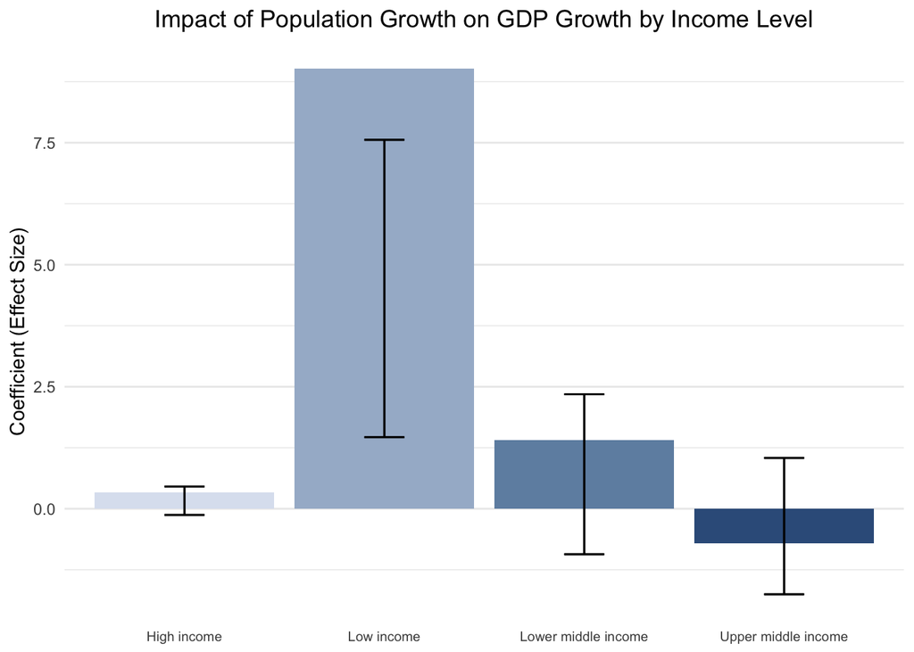

```r
# Create a visualization with updated settings
ggplot(results_table, aes(x = Income_Level, y = Coefficient, fill = Income_Level)) +
  geom_bar(stat = "identity", show.legend = FALSE) +
  geom_errorbar(aes(ymin = Coefficient - 1.96 * Std_Error, ymax = Coefficient + 1.96 * Std_Error), width = 0.2) +
  scale_fill_manual(values = c("#dce3f0", "#a5b8d0", "#6f8fb0", "#375d8a")) + # Shades of blue-gray
  labs(
    title = "Impact of Population Growth on GDP Growth by Income Level",
    y = "Coefficient (Effect Size)" # Removed x-axis label
  ) +
  theme_minimal() +
  theme(
    axis.text.x = element_text(size = rel(0.85), hjust = 0.5, vjust = 0.5), # Reduce x-axis text size to 75%
    axis.title.x = element_blank(), # Remove x-axis label
    plot.title = element_text(hjust = 0.5), # Centered title
    panel.grid.major.x = element_blank() # Optional: Clean grid
  )
```